# Scientifc Modules III

## Table of content

1. SciPy
2. Matplotlib
3. Exercise 59 - Some Plots

# Scientifc Modules III

## SciPy

Scipy is a colletion of mathematical algorithms built on NumPy

The subpackages need to be imported separately, e.g.

```
from scipy import linalg, optimize
```

functions are then used with `.`notation

```
linalg.inv(matrix)
```

A list of subpackages is in the powerpoint, SciPy has its own website: https://scipy.org

## Matplotlib

A comprehensive library for creating static, animated, and interactive visualizations in Python.  
To use in Python the submodule pyplot is needed:

```
import matplotlib.pyplot as plt
```

some plottypes, all are called with plt.name():

- plot (scatter or line plots)
- bar (vertical bars)
- errorbar (scatter or line plots with errorbars)
- barh (horizontal bars)
- hist (histograms)
- contour (contour plots?
- imshow (heatmap)
- pie
- plot_surface
- bar3d

Modifications similar to ggplot in having them added underneath the call of the plot

- tilte
- xlabel
- ylabel
- xlim
- ylim
- xticks
- yticks
- grid
- legend

```python
import matplotlib.pyplot as plt
```

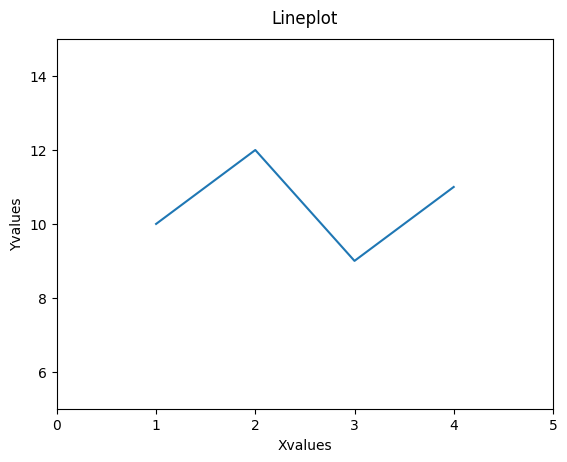

```python
#some data
xvalues = [1,2,3,4]
yvalues = [10,12,9,11]

# first create the canvas (at least in Jupyter I don't need this)
#plt.figure()
# draw a diagram
plt.plot(xvalues,yvalues)

## modify (this has to be in the same box in Jupyter Notebook!)

#add a title a bit further up than default
plt.title("Lineplot", y = 1.02)
#add Axis Labels
plt.xlabel("Xvalues")
plt.ylabel("Yvalues")
#specifiy the limits of the axes
plt.xlim([0,5])
plt.ylim([5,15])

#etc. etc.
#for legends etc. see powerpoint

# show the plot. I need it in Jupyter too if sth comes after it
plt.show()

#OR (you cannot do both in Thonny. In Jupyter I can save it an it is shown anyway)

#save the plot in workind directory
#plt.savefig("Image.png")

# close the canvas with (again, not sure I need this in Jupyter. Yes it is if you want todrwa another plot)
plt.close()
```

## Exercise 59 – Some Plots

Write a python script that creates the following three different plots with the help of Matplotlib:

- a Lineplot with at least 10 datapoints
- a Scatterplot with at least 500 datapoints
- a bar diagram with at least 15 bars

Format your plots accordingly by:

- adding title, Axes labels
- specifying Limits, intervals and interval labels for both Axes

Afterwards save your plots as png images.

```python
import random
```

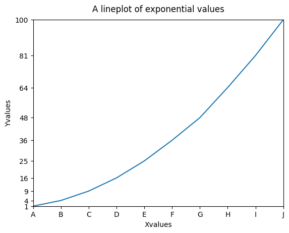

```python
##a Lineplot with at least 10 datapoints
#some data
xvalues1 = list(range(1,11))
yvalues1 = [1,4,9,16,25,36,48,64,81,100]

plt.plot(xvalues1,yvalues1)
#add title
plt.title("A lineplot of exponential values", y = 1.02)
#add Axis Labels
plt.xlabel("Xvalues")
plt.ylabel("Yvalues")
#specifiy the limits of the axes
plt.xlim([1,10])
plt.ylim([1,100])

plt.xticks (xvalues1,["A","B","C","D","E","F","G","H","I","J"])

plt.yticks (yvalues1)
plt.show()
#plt.savefig("Image1.png")
plt.close()
```

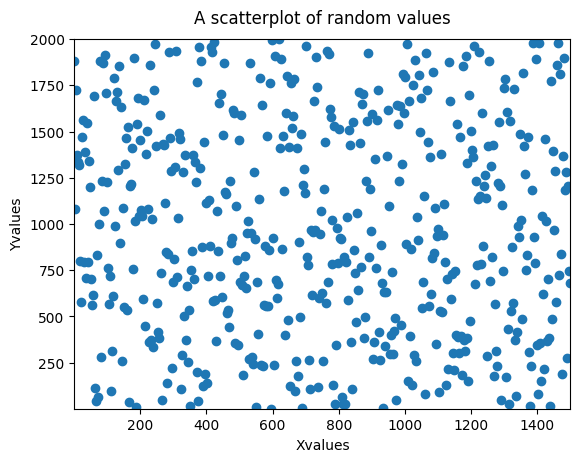

```python
##a Scatterplot with at least 500 datapoints
#some data
xvalues2 = list(range(1,1501,3))
yvalues2 = random.sample(list(range(2000)), 500)

plt.plot(xvalues2,yvalues2,'o')
#add title
plt.title("A scatterplot of random values", y = 1.02)
#add Axis Labels
plt.xlabel("Xvalues")
plt.ylabel("Yvalues")
#specifiy the limits of the axes
plt.xlim([1,1500])
plt.ylim([1,2000])

#plt.xticks (xvalues,["A","B","C","D","E","F","G","H","I","J"])

#plt.yticks (yvalues)
plt.show()
#plt.savefig("Image2a.png")
plt.close()
```

```python
yvalues2b = random.sample(list(range(400)), 100)
yvalues2b.extend(random.sample(list(range(400,800)), 100))
yvalues2b.extend(random.sample(list(range(800,1200)), 100))
yvalues2b.extend(random.sample(list(range(1200,1600)), 100))
yvalues2b.extend(random.sample(list(range(1600,2000)), 100))
print(len(yvalues2b))
```

```
500
```

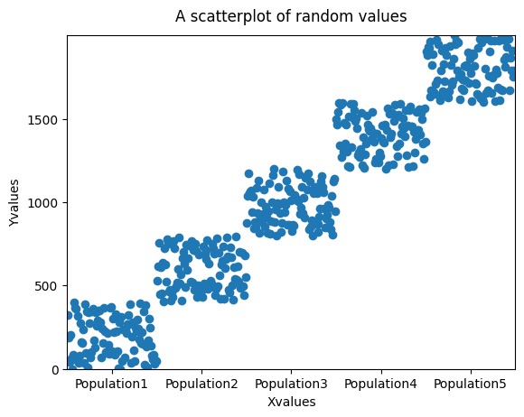

```python
## make the scatterplot a bit more interesting

plt.plot(xvalues2,yvalues2b,'o')
#add title
plt.title("A scatterplot of random values", y = 1.02)
#add Axis Labels
plt.xlabel("Xvalues")
plt.ylabel("Yvalues")
#specifiy the limits of the axes
plt.xlim([0,1500])
plt.ylim([0,2000])
plt.xticks ([150,450,750,1050,1350],["Population1","Population2","Population3","Population4","Population5"])
plt.yticks ([0,500,1000,1500])
plt.show()
#plt.savefig("Image2b.png")
plt.close()
```

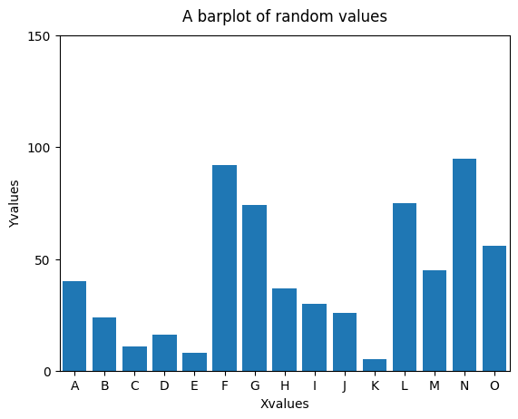

```python
## a bar diagram with at least 15 bars
#some data
xvalues3 = list(range(1,16))
yvalues3 = random.sample(list(range(100)), 15)

plt.bar(xvalues3,yvalues3)
#add title
plt.title("A barplot of random values", y = 1.02)
#add Axis Labels
plt.xlabel("Xvalues")
plt.ylabel("Yvalues")
#specifiy the limits of the axes
plt.xlim([0.5,15.5])
plt.ylim([0,150])
plt.xticks (xvalues3,["A","B","C","D","E","F","G","H","I","J","K","L","M","N","O"])
plt.yticks ([0,50,100,150])
plt.show()
#plt.savefig("Image3.png")
plt.close()
```